# ps6ans

EC404 ps6

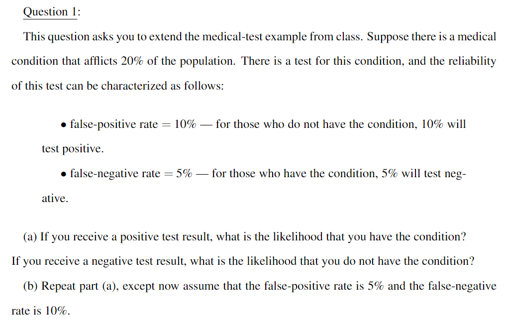

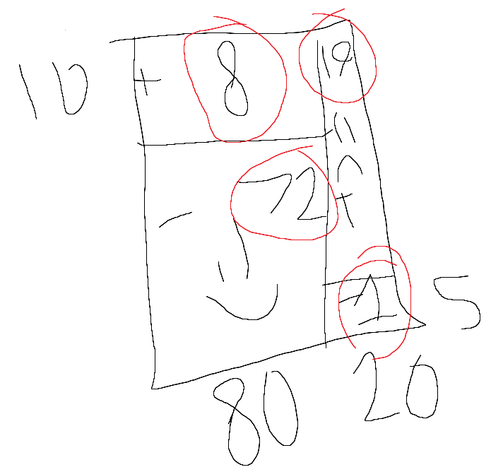

(a) P(sick|+) = P(sick)P(+|sick)/P(+) = .19/(.08+.19) = 70%  
(b) = .18/(.04+.18) = 81%

Q2:

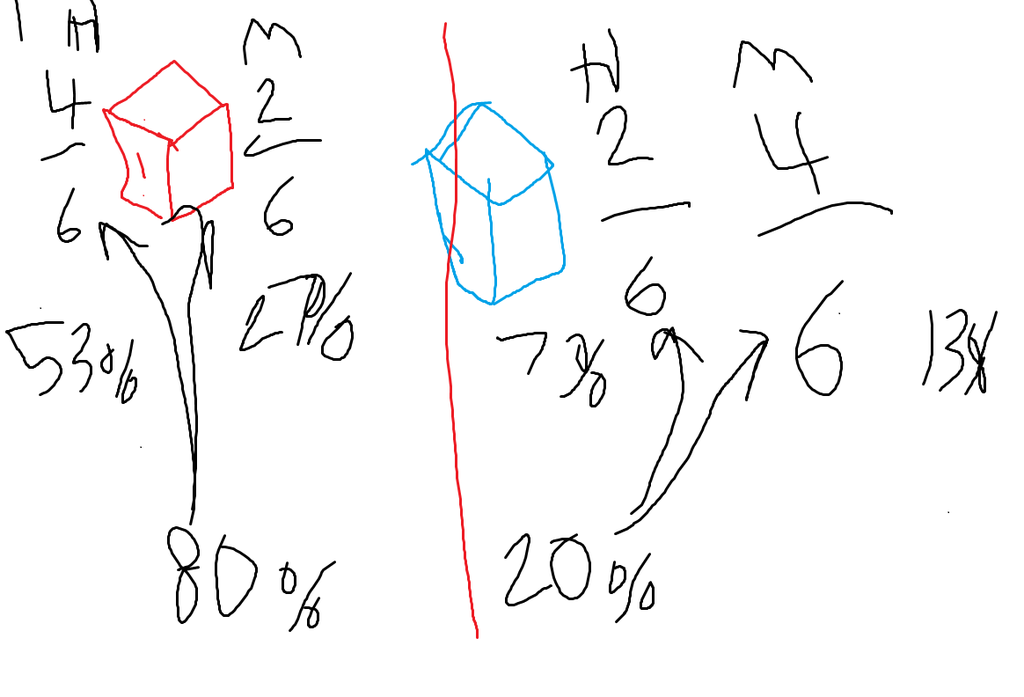

(a) Certainly not over-infrence, since 50/50 is the most conservative result. This is conservativism as this outcome is more common for red and the base rate is already 80%. Still not the worst answer, since the small sample size leaves things close to 50/50

(b) This person judges very accurately. After 3 rolls, 2H and 1 M has a 14.8% chance of occcuring for red and 7.4% chance of occuring for blue, yielding a 14.8/22.2 = 66% chance of occuring when the base rate is 50/50. Alongside the base rate of 80% red, the actual probability of this outcome should be even greater than 80%. Perhaps there is some over-infrence from small samples, but they're in the right direction.

(c) This is likely an example of base rate neglect. Even with a 50/50 base rate this has a $(2/6)^4(4/6)^6$ portion for red and $(4/6)^4(2/6)^2$ portion for blue, yielding an 80% chance of it being red. In reality the likelyhood of it being red is much higher than 9/10

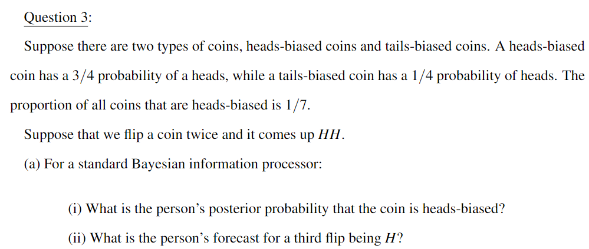

Prior = 1/7 HB and 6/7 TB Posterior = after result

Probability of HB getting this result: $9/16 = .56$  
Probability of TB getting this result: $1/16 = .07$  
Probability of this outcome: $1/7*9/16 + 6/7 * 1/16 = 15/112$  
Posterior Probability of HB: $\dfrac{1/7*9/16}{15/112}= 3/5 = .60$

Prob of H = Prob of H from HB + Prob of H from TB = $3/5 * 3/4 + 2/5 * 1/4 = 11/20 = 0.55$

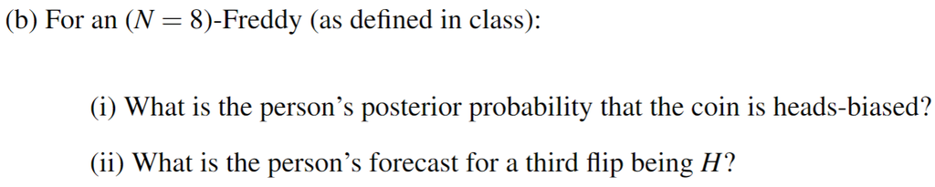

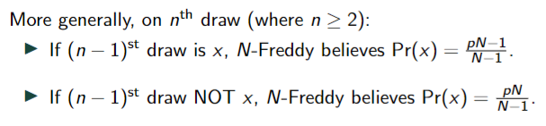

N-Freddy only updates probability based on the previous draw.

For (i) we do bayes to update probabilites

HH|HB = $3/4 * \text{Pr}(3/4) = 3/4 * \frac{3/4(8)-1}{7} = 15 / 28 = .54$ not too far off  
HH|TB = $1/4 * \text{Pr}(1/4) = 1/4 * \frac{1/4(8)-1}{7} = 1/28 = .04$

Freddy's Bayes prob of HB: $\frac{.54*1/7}{.04*6/7+.54*1/7} = 0.69$

Third H: $.69 * \frac{3/4(8)-1}{7} + (1-.69) \frac{1/4(8)-1}{7} = 0.54 $ Suprisingly accurate

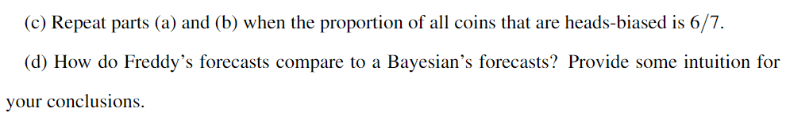

(d)  
8-Freddy's forecasts aren't too far off compared to the actual values, but in the original scenario he doesn't properly account for base-rates and overadjusts his belief that the die is HB. 8-Freddy tends to undervalue the third heads each time since his gambler's fallacy pushes him to expect a tails next.

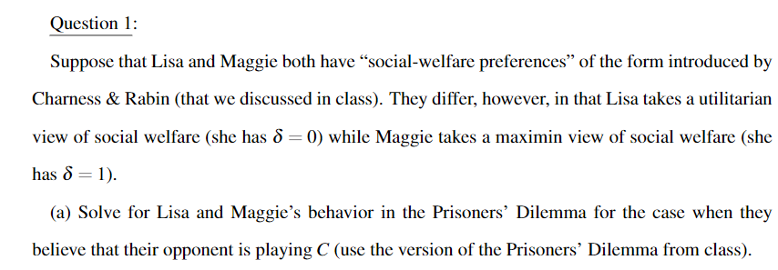

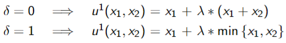

We'll use the standard prisoners dilema with $3,3;0,4;4,0;1,1$.

$\delta = 1$ Maggie has $u(c) = 3 + \lambda (3)$ vs $u(D) = 4 $  
As such, Maggie chooses C for $\lambda > 1/3$

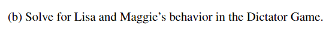

Without loss of generality, lets say P = 1

Lisa $u(s) = (1-s) + \lambda $ Lisa doesn't share $s=0$

Maggie $u(s) = (1-s) + \lambda X(s)$ where $X(s) = \begin{cases} s & s\leq0.5 \\ 1-s & s>0.5 \end{cases}$  
The minimum Maggie can earn is $1$, and earns the most due to sharing when $0.5 + \lambda 0.5$, Maggie will shre for $\lambda \geq 1$

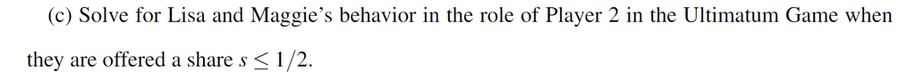

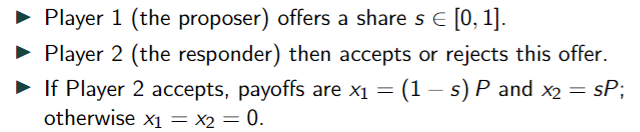

With $P=1$, Lisa's earnings are $s + \lambda$ for accepting and $0$ for rejecting, so she always accepts

Maggie earns $s + \lambda s$ for accepting and $0$ for rejecting, so she always accepts

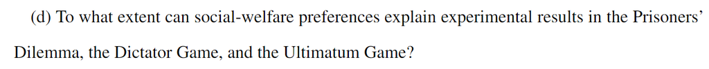

Prisoner's and Dictators seems to align well with the real world. Different outcomes in Dictator Game and Prisoners Dilema are well explained by varying the $\lambda$ value, as a variety of choices make sense. The Ultimatum game includes a bit more revenge than what these models explain.

Question 2: SKIPPED!

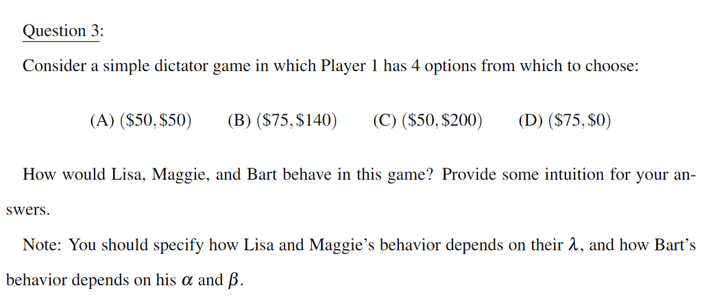

We can calculate Lisa and Maggie's behavior in this game, but no matter what Lisa will choose B or C depending on her $\lambda$ and Maggie will choose B, since she wants to maximizer the smallest number and her own utility.

Question 4 SKIPPED. Sorry, ran out of time. I did most of it though!